# Анализ бизнес - показателей

В распоряжении есть данные о пользователях приложения, привлечённых с 1 мая по 27 октября 2019 года:

- лог сервера с данными об их посещениях;
- выгрузка их покупок за этот период;
- рекламные расходы.

## Цель проекта

Выявление причин убытков, несмотря на вложения в рекламу.

## Выводы исследования

переход к выводам

## Оглавление

Описание данных

1. Изучение данных
1. Функции для расчёта и анализа LTV, ROI, удержания и конверсии

   2.1 Функция для создания пользовательских профилей

   2.2 Функция для расчета удержания

   2.3 Функция для расчета конверсии

   2.4 Функция для расчета LTV и ROI

   2.5 Функция для сглаживания фрейма

   2.6 Функция для визуализации удержания

   2.7 Функция для визуализации конверсии

   2.8 Функция для визуализации LTV и ROI
1. Исследовательский анализ данных

   3.1 Составление профилей пользователей

   3.2 Распределение пользователей по странам

   3.3 Распределение пользователей по устройствам

   3.4 Распределение пользователей по рекламным каналам

   3.5 Вывод по исследовательскому анализу данных
1. Маркетинг

   4.1 Подсчёт общей суммы расходов на маркетинг

   4.2 Распределение трат по рекламным источникам

   4.3 Построение визуализации динамики изменения расходов по неделям и месяцам

   4.4 Стоимость привлечения пользователей

   4.5 Вывод по маркетингу
1. Оценка окупаемости рекламы

   5.1 Анализ окупаемости c помощью графиков LTV и ROI

   5.2 Окупаемость рекламы с разбивкой по устройствам

   5.3 Окупаемость рекламы с разбивкой по странам

   5.4 Окупаемость рекламы с разбивкой по рекламным каналам

   5.5 Конверсия пользователей

   5.6 Конверсия пользователей по регионам

   5.7 Выводы по окупаемости
1. Каналы, устройства, платформы

   6.1 Распределение каналов по странам

   6.2 Распределение устройств по каналам

   6.3 Популярность девайсов

   6.4 Привлеченные пользователи по каналам и устройствам

   6.5 Выводы по разделу
1. Проседающие каналы
1. Общий вывод

## Описание данных

Структура visits_info_short.csv:

- User Id — уникальный идентификатор пользователя,
- Region — страна пользователя,
- Device — тип устройства пользователя,
- Channel — идентификатор источника перехода,
- Session Start — дата и время начала сессии,
- Session End — дата и время окончания сессии.

Структура orders_info_short.csv:

- User Id — уникальный идентификатор пользователя,
- Event Dt — дата и время покупки,
- Revenue — сумма заказа.

Структура costs_info_short.csv:

- dt — дата проведения рекламной кампании,
- Channel — идентификатор рекламного источника,
- costs — расходы на эту кампанию.

переход к оглавлению

## Изучение данных

```python
#импорт библиотек
import pandas as pd
import numpy as np
from datetime import datetime, timedelta
from matplotlib import pyplot as plt
import seaborn as sns
sns.set()
```

```python
#чтение датасета, сохранение в переменные
visits, orders, costs = (
    pd.read_csv(r'C:\Users\User\My Jupyter Projects\Анализ бизнес-показателей\visits_info_short.csv'), #визиты
    pd.read_csv(r'C:\Users\User\My Jupyter Projects\Анализ бизнес-показателей\orders_info_short.csv'), #заказы
    pd.read_csv(r'C:\Users\User\My Jupyter Projects\Анализ бизнес-показателей\costs_info_short.csv')   #расходы
)
```

```python
#просмотр информации о таблицах, проверка на наличие дубликатов
for i in [visits, orders, costs]:
    display(i.head())
    display(i.info())
    display(i.duplicated().sum())
```

|  | User Id | Region | Device | Channel | Session Start | Session End |
| --- | --- | --- | --- | --- | --- | --- |
| 0 | 981449118918 | United States | iPhone | organic | 2019-05-01 02:36:01 | 2019-05-01 02:45:01 |
| 1 | 278965908054 | United States | iPhone | organic | 2019-05-01 04:46:31 | 2019-05-01 04:47:35 |
| 2 | 590706206550 | United States | Mac | organic | 2019-05-01 14:09:25 | 2019-05-01 15:32:08 |
| 3 | 326433527971 | United States | Android | TipTop | 2019-05-01 00:29:59 | 2019-05-01 00:54:25 |
| 4 | 349773784594 | United States | Mac | organic | 2019-05-01 03:33:35 | 2019-05-01 03:57:40 |

```
<class 'pandas.core.frame.DataFrame'>
RangeIndex: 309901 entries, 0 to 309900
Data columns (total 6 columns):
 #   Column         Non-Null Count   Dtype
---  ------         --------------   -----
 0   User Id        309901 non-null  int64
 1   Region         309901 non-null  object
 2   Device         309901 non-null  object
 3   Channel        309901 non-null  object
 4   Session Start  309901 non-null  object
 5   Session End    309901 non-null  object
dtypes: int64(1), object(5)
memory usage: 14.2+ MB
```

```
None
```

```
0
```

|  | User Id | Event Dt | Revenue |
| --- | --- | --- | --- |
| 0 | 188246423999 | 2019-05-01 23:09:52 | 4.99 |
| 1 | 174361394180 | 2019-05-01 12:24:04 | 4.99 |
| 2 | 529610067795 | 2019-05-01 11:34:04 | 4.99 |
| 3 | 319939546352 | 2019-05-01 15:34:40 | 4.99 |
| 4 | 366000285810 | 2019-05-01 13:59:51 | 4.99 |

```
<class 'pandas.core.frame.DataFrame'>
RangeIndex: 40212 entries, 0 to 40211
Data columns (total 3 columns):
 #   Column    Non-Null Count  Dtype
---  ------    --------------  -----
 0   User Id   40212 non-null  int64
 1   Event Dt  40212 non-null  object
 2   Revenue   40212 non-null  float64
dtypes: float64(1), int64(1), object(1)
memory usage: 942.6+ KB
```

```
None
```

```
0
```

|  | dt | Channel | costs |
| --- | --- | --- | --- |
| 0 | 2019-05-01 | FaceBoom | 113.3 |
| 1 | 2019-05-02 | FaceBoom | 78.1 |
| 2 | 2019-05-03 | FaceBoom | 85.8 |
| 3 | 2019-05-04 | FaceBoom | 136.4 |
| 4 | 2019-05-05 | FaceBoom | 122.1 |

```
<class 'pandas.core.frame.DataFrame'>
RangeIndex: 1800 entries, 0 to 1799
Data columns (total 3 columns):
 #   Column   Non-Null Count  Dtype
---  ------   --------------  -----
 0   dt       1800 non-null   object
 1   Channel  1800 non-null   object
 2   costs    1800 non-null   float64
dtypes: float64(1), object(2)
memory usage: 42.3+ KB
```

```
None
```

```
0
```

Пропусков в данных нет, однако названия колонок не соответствуют стилю. Большинство колонок начинается с заглавных букв, а в составных названиях отсутствует нижнее подчеркивание.

```python
#приведение столбцов к стилю snake_case
for i in [visits, orders, costs]:
    i.columns = [x.lower().replace(' ', '_') for x in i.columns.values]
```

```python
# преобразование данных о времени
visits['session_start'] = pd.to_datetime(visits['session_start'])
visits['session_end'] = pd.to_datetime(visits['session_end'])
orders['event_dt'] = pd.to_datetime(orders['event_dt'])
costs['dt'] = pd.to_datetime(costs['dt']).dt.date
```

Данные готовы к анализу.

переход к оглавлению

## Функции для расчёта и анализа LTV, ROI, удержания и конверсии

### Функция для создания пользовательских профилей

```python
def get_profiles(sessions, orders, costs):
    # находим параметры первых посещений
    profiles = (sessions.sort_values(by=['user_id', 'session_start'])
                .groupby('user_id')
                .agg(
                    {
                        'session_start' : 'first',
                        'channel' : 'first',
                        'device' : 'first',
                        'region' : 'first'
                    }
                )
                .rename(columns={'session_start' : 'first_ts'})
                .reset_index()
               )

    # для когортного анализа определяем дату первого посещения
    # и первый день месяца, в который это посещение произошло
    profiles['dt'] = profiles['first_ts'].dt.date
    profiles['month'] = profiles['first_ts'].astype('datetime64[M]')

    # добавляем признак пользователей, совершивших покупку
    profiles['payer'] = profiles['user_id'].isin(orders['user_id'].unique())

    # считаем количество уникальных пользователей
    # с одинаковыми источником и датой привлечения
    new_users = (
        profiles.groupby(['dt', 'channel'])
        .agg({'user_id': 'nunique'})
        .rename(columns={'user_id': 'unique_users'})
        .reset_index()
    )

    # объединяем траты на рекламу и число привлечённых пользователей
    ad_costs = costs.merge(new_users, on=['dt', 'channel'], how='left')

    # делим рекламные расходы на число привлечённых пользователей
    ad_costs['acquisition_cost'] = ad_costs['costs'] / ad_costs['unique_users']

    # добавляем стоимость привлечения в профили
    profiles = profiles.merge(
        ad_costs[['dt', 'channel', 'acquisition_cost']],
        on=['dt', 'channel'],
        how='left',
    )

    # стоимость привлечения органических пользователей равна нулю
    profiles['acquisition_cost'] = profiles['acquisition_cost'].fillna(0)

    return profiles
```

переход к оглавлению

### Функция для расчета удержания

```python
def get_retention(
    profiles,
    sessions,
    observation_date,
    horizon_days,
    dimensions=[],
    ignore_horizon=False,
):
    # добавляем столбец payer в передаваемый dimensions список
    dimensions = ['payer'] + dimensions

    # исключаем пользователей, не «доживших» до горизонта анализа
    last_suitable_acquisition_date = observation_date
    if not ignore_horizon:
        last_suitable_acquisition_date = observation_date - timedelta(days=horizon_days - 1)
    result_raw  = profiles.query('dt <= @last_suitable_acquisition_date')

    # собираем «сырые» данные для расчёта удержания
    result_raw = result_raw.merge(
        sessions[['user_id', 'session_start']], on='user_id', how='left'
    )
    result_raw['lifetime'] = (
        result_raw['session_start'] - result_raw['first_ts']
    ).dt.days

    # функция для группировки таблицы по желаемым признакам
    def group_by_dimensions(df, dims, horizon_days):
        result = df.pivot_table(
            index=dims, columns='lifetime', values='user_id', aggfunc='nunique'
        )
        cohort_sizes = (
            df.groupby(dims)
            .agg({'user_id': 'nunique'})
            .rename(columns={'user_id': 'cohort_size'})
        )
        result = cohort_sizes.merge(result, on=dims, how='left').fillna(0)
        result = result.div(result['cohort_size'], axis=0)
        result = result[['cohort_size'] + list(range(horizon_days))]
        result['cohort_size'] = cohort_sizes
        return result

    # получаем таблицу удержания
    result_grouped = group_by_dimensions(result_raw, dimensions, horizon_days)

    # получаем таблицу динамики удержания
    result_in_time = group_by_dimensions(
        result_raw, dimensions + ['dt'], horizon_days
    )

    # возвращаем обе таблицы и сырые данные
    return result_raw, result_grouped, result_in_time
```

переход к оглавлению

### Функция для расчета конверсии

```python
# функция для расчёта конверсии

def get_conversion(
    profiles,
    purchases,
    observation_date,
    horizon_days,
    dimensions=[],
    ignore_horizon=False,
):

    # исключаем пользователей, не «доживших» до горизонта анализа
    last_suitable_acquisition_date = observation_date
    if not ignore_horizon:
        last_suitable_acquisition_date = observation_date - timedelta(
            days=horizon_days - 1
        )
    result_raw = profiles.query('dt <= @last_suitable_acquisition_date')

    # определяем дату и время первой покупки для каждого пользователя
    first_purchases = (
        purchases.sort_values(by=['user_id', 'event_dt'])
        .groupby('user_id')
        .agg({'event_dt': 'first'})
        .reset_index()
    )

    # добавляем данные о покупках в профили
    result_raw = result_raw.merge(
        first_purchases[['user_id', 'event_dt']], on='user_id', how='left'
    )

    # рассчитываем лайфтайм для каждой покупки
    result_raw['lifetime'] = (
        result_raw['event_dt'] - result_raw['first_ts']
    ).dt.days

    # группируем по cohort, если в dimensions ничего нет
    if len(dimensions) == 0:
        result_raw['cohort'] = 'All users'
        dimensions = dimensions + ['cohort']

    # функция для группировки таблицы по желаемым признакам
    def group_by_dimensions(df, dims, horizon_days):
        result = df.pivot_table(
            index=dims, columns='lifetime', values='user_id', aggfunc='nunique'
        )
        result = result.fillna(0).cumsum(axis = 1)
        cohort_sizes = (
            df.groupby(dims)
            .agg({'user_id': 'nunique'})
            .rename(columns={'user_id': 'cohort_size'})
        )
        result = cohort_sizes.merge(result, on=dims, how='left').fillna(0)
        # делим каждую «ячейку» в строке на размер когорты
        # и получаем conversion rate
        result = result.div(result['cohort_size'], axis=0)
        result = result[['cohort_size'] + list(range(horizon_days))]
        result['cohort_size'] = cohort_sizes
        return result

    # получаем таблицу конверсии
    result_grouped = group_by_dimensions(result_raw, dimensions, horizon_days)

    # для таблицы динамики конверсии убираем 'cohort' из dimensions
    if 'cohort' in dimensions:
        dimensions = []

    # получаем таблицу динамики конверсии
    result_in_time = group_by_dimensions(
        result_raw, dimensions + ['dt'], horizon_days
    )

    # возвращаем обе таблицы и сырые данные
    return result_raw, result_grouped, result_in_time
```

переход к оглавлению

### Функция для расчета LTV и ROI

```python
# функция для расчёта LTV и ROI

def get_ltv(
    profiles,
    purchases,
    observation_date,
    horizon_days,
    dimensions=[],
    ignore_horizon=False,
):

    # исключаем пользователей, не «доживших» до горизонта анализа
    last_suitable_acquisition_date = observation_date
    if not ignore_horizon:
        last_suitable_acquisition_date = observation_date - timedelta(
            days=horizon_days - 1
        )
    result_raw = profiles.query('dt <= @last_suitable_acquisition_date')

    # добавляем данные о покупках в профили
    result_raw = result_raw.merge(
        purchases[['user_id', 'event_dt', 'revenue']], on='user_id', how='left'
    )
    # рассчитываем лайфтайм пользователя для каждой покупки
    result_raw['lifetime'] = (
        result_raw['event_dt'] - result_raw['first_ts']
    ).dt.days
    # группируем по cohort, если в dimensions ничего нет
    if len(dimensions) == 0:
        result_raw['cohort'] = 'All users'
        dimensions = dimensions + ['cohort']

    # функция группировки по желаемым признакам
    def group_by_dimensions(df, dims, horizon_days):
        # строим «треугольную» таблицу выручки
        result = df.pivot_table(
            index=dims, columns='lifetime', values='revenue', aggfunc='sum'
        )
        # находим сумму выручки с накоплением
        result = result.fillna(0).cumsum(axis=1)
        # вычисляем размеры когорт
        cohort_sizes = (
            df.groupby(dims)
            .agg({'user_id': 'nunique'})
            .rename(columns={'user_id': 'cohort_size'})
        )
        # объединяем размеры когорт и таблицу выручки
        result = cohort_sizes.merge(result, on=dims, how='left').fillna(0)
        # считаем LTV: делим каждую «ячейку» в строке на размер когорты
        result = result.div(result['cohort_size'], axis=0)
        # исключаем все лайфтаймы, превышающие горизонт анализа
        result = result[['cohort_size'] + list(range(horizon_days))]
        # восстанавливаем размеры когорт
        result['cohort_size'] = cohort_sizes

        # собираем датафрейм с данными пользователей и значениями CAC,
        # добавляя параметры из dimensions
        cac = df[['user_id', 'acquisition_cost'] + dims].drop_duplicates()

        # считаем средний CAC по параметрам из dimensions
        cac = (
            cac.groupby(dims)
            .agg({'acquisition_cost': 'mean'})
            .rename(columns={'acquisition_cost': 'cac'})
        )

        # считаем ROI: делим LTV на CAC
        roi = result.div(cac['cac'], axis=0)

        # удаляем строки с бесконечным ROI
        roi = roi[~roi['cohort_size'].isin([np.inf])]

        # восстанавливаем размеры когорт в таблице ROI
        roi['cohort_size'] = cohort_sizes

        # добавляем CAC в таблицу ROI
        roi['cac'] = cac['cac']

        # в финальной таблице оставляем размеры когорт, CAC
        # и ROI в лайфтаймы, не превышающие горизонт анализа
        roi = roi[['cohort_size', 'cac'] + list(range(horizon_days))]

        # возвращаем таблицы LTV и ROI
        return result, roi

    # получаем таблицы LTV и ROI
    result_grouped, roi_grouped = group_by_dimensions(
        result_raw, dimensions, horizon_days
    )

    # для таблиц динамики убираем 'cohort' из dimensions
    if 'cohort' in dimensions:
        dimensions = []

    # получаем таблицы динамики LTV и ROI
    result_in_time, roi_in_time = group_by_dimensions(
        result_raw, dimensions + ['dt'], horizon_days
    )

    return (
        result_raw,  # сырые данные
        result_grouped,  # таблица LTV
        result_in_time,  # таблица динамики LTV
        roi_grouped,  # таблица ROI
        roi_in_time,  # таблица динамики ROI
    )
```

переход к оглавлению

### Функция для сглаживания фрейма

```python
# функция для сглаживания фрейма

def filter_data(df, window):
    # для каждого столбца применяем скользящее среднее
    for column in df.columns.values:
        df[column] = df[column].rolling(window).mean()
    return df
```

переход к оглавлению

### Функция для визуализации удержания

```python
# функция для визуализации удержания

def plot_retention(retention, retention_history, horizon, window=7):

    # задаём размер сетки для графиков
    plt.figure(figsize=(15, 10))

    # исключаем размеры когорт и удержание первого дня
    retention = retention.drop(columns=['cohort_size', 0])
    # в таблице динамики оставляем только нужный лайфтайм
    retention_history = retention_history.drop(columns=['cohort_size'])[
        [horizon - 1]
    ]

    # если в индексах таблицы удержания только payer,
    # добавляем второй признак — cohort
    if retention.index.nlevels == 1:
        retention['cohort'] = 'All users'
        retention = retention.reset_index().set_index(['cohort', 'payer'])

    # в таблице графиков — два столбца и две строки, четыре ячейки
    # в первой строим кривые удержания платящих пользователей
    ax1 = plt.subplot(2, 2, 1)
    retention.query('payer == True').droplevel('payer').T.plot(
        grid=True, ax=ax1
    )
    plt.legend()
    plt.xlabel('Лайфтайм')
    plt.title('Удержание платящих пользователей')

    # во второй ячейке строим кривые удержания неплатящих
    # вертикальная ось — от графика из первой ячейки
    ax2 = plt.subplot(2, 2, 2, sharey=ax1)
    retention.query('payer == False').droplevel('payer').T.plot(
        grid=True, ax=ax2
    )
    plt.legend()
    plt.xlabel('Лайфтайм')
    plt.title('Удержание неплатящих пользователей')

    # в третьей ячейке — динамика удержания платящих
    ax3 = plt.subplot(2, 2, 3)
    # получаем названия столбцов для сводной таблицы
    columns = [
        name
        for name in retention_history.index.names
        if name not in ['dt', 'payer']
    ]
    # фильтруем данные и строим график
    filtered_data = retention_history.query('payer == True').pivot_table(
        index='dt', columns=columns, values=horizon - 1, aggfunc='mean'
    )
    filter_data(filtered_data, window).plot(grid=True, ax=ax3)
    plt.xlabel('Дата привлечения')
    plt.title(
        'Динамика удержания платящих пользователей на {}-й день'.format(
            horizon
        )
    )

    # в чётвертой ячейке — динамика удержания неплатящих
    ax4 = plt.subplot(2, 2, 4, sharey=ax3)
    # фильтруем данные и строим график
    filtered_data = retention_history.query('payer == False').pivot_table(
        index='dt', columns=columns, values=horizon - 1, aggfunc='mean'
    )
    filter_data(filtered_data, window).plot(grid=True, ax=ax4)
    plt.xlabel('Дата привлечения')
    plt.title(
        'Динамика удержания неплатящих пользователей на {}-й день'.format(
            horizon
        )
    )

    plt.tight_layout()
    plt.show()
```

переход к оглавлению

### Функция для визуализации конверсии

```python
# функция для визуализации конверсии

def plot_conversion(conversion, conversion_history, horizon, window=7):

    # задаём размер сетки для графиков
    plt.figure(figsize=(15, 5))

    # исключаем размеры когорт
    conversion = conversion.drop(columns=['cohort_size'])
    # в таблице динамики оставляем только нужный лайфтайм
    conversion_history = conversion_history.drop(columns=['cohort_size'])[
        [horizon - 1]
    ]

    # первый график — кривые конверсии
    ax1 = plt.subplot(1, 2, 1)
    conversion.T.plot(grid=True, ax=ax1)
    plt.legend()
    plt.xlabel('Лайфтайм')
    plt.title('Конверсия пользователей')

    # второй график — динамика конверсии
    ax2 = plt.subplot(1, 2, 2, sharey=ax1)
    columns = [
        # столбцами сводной таблицы станут все столбцы индекса, кроме даты
        name for name in conversion_history.index.names if name not in ['dt']
    ]
    filtered_data = conversion_history.pivot_table(
        index='dt', columns=columns, values=horizon - 1, aggfunc='mean'
    )
    filter_data(filtered_data, window).plot(grid=True, ax=ax2)
    plt.xlabel('Дата привлечения')
    plt.title('Динамика конверсии пользователей на {}-й день'.format(horizon))

    plt.tight_layout()
    plt.show()
```

переход к оглавлению

### Функция для визуализации LTV и ROI

```python
# функция для визуализации LTV и ROI

def plot_ltv_roi(ltv, ltv_history, roi, roi_history, horizon, window=7):

    # задаём сетку отрисовки графиков
    plt.figure(figsize=(20, 10))

    # из таблицы ltv исключаем размеры когорт
    ltv = ltv.drop(columns=['cohort_size'])
    # в таблице динамики ltv оставляем только нужный лайфтайм
    ltv_history = ltv_history.drop(columns=['cohort_size'])[[horizon - 1]]

    # стоимость привлечения запишем в отдельный фрейм
    cac_history = roi_history[['cac']]

    # из таблицы roi исключаем размеры когорт и cac
    roi = roi.drop(columns=['cohort_size', 'cac'])
    # в таблице динамики roi оставляем только нужный лайфтайм
    roi_history = roi_history.drop(columns=['cohort_size', 'cac'])[
        [horizon - 1]
    ]

    # первый график — кривые ltv
    ax1 = plt.subplot(2, 3, 1)
    ltv.T.plot(grid=True, ax=ax1)
    plt.legend()
    plt.xlabel('Лайфтайм')
    plt.title('LTV')

    # второй график — динамика ltv
    ax2 = plt.subplot(2, 3, 2, sharey=ax1)
    # столбцами сводной таблицы станут все столбцы индекса, кроме даты
    columns = [name for name in ltv_history.index.names if name not in ['dt']]
    filtered_data = ltv_history.pivot_table(
        index='dt', columns=columns, values=horizon - 1, aggfunc='mean'
    )
    filter_data(filtered_data, window).plot(grid=True, ax=ax2)
    plt.xlabel('Дата привлечения')
    plt.title('Динамика LTV пользователей на {}-й день'.format(horizon))

    # третий график — динамика cac
    ax3 = plt.subplot(2, 3, 3, sharey=ax1)
    # столбцами сводной таблицы станут все столбцы индекса, кроме даты
    columns = [name for name in cac_history.index.names if name not in ['dt']]
    filtered_data = cac_history.pivot_table(
        index='dt', columns=columns, values='cac', aggfunc='mean'
    )
    filter_data(filtered_data, window).plot(grid=True, ax=ax3)
    plt.xlabel('Дата привлечения')
    plt.title('Динамика стоимости привлечения пользователей')

    # четвёртый график — кривые roi
    ax4 = plt.subplot(2, 3, 4)
    roi.T.plot(grid=True, ax=ax4)
    plt.axhline(y=1, color='red', linestyle='--', label='Уровень окупаемости')
    plt.legend()
    plt.xlabel('Лайфтайм')
    plt.title('ROI')

    # пятый график — динамика roi
    ax5 = plt.subplot(2, 3, 5, sharey=ax4)
    # столбцами сводной таблицы станут все столбцы индекса, кроме даты
    columns = [name for name in roi_history.index.names if name not in ['dt']]
    filtered_data = roi_history.pivot_table(
        index='dt', columns=columns, values=horizon - 1, aggfunc='mean'
    )
    filter_data(filtered_data, window).plot(grid=True, ax=ax5)
    plt.axhline(y=1, color='red', linestyle='--', label='Уровень окупаемости')
    plt.xlabel('Дата привлечения')
    plt.title('Динамика ROI пользователей на {}-й день'.format(horizon))

    plt.tight_layout()
    plt.show()
```

Функции заданы, переходим к исследовательскому анализу данных.

переход к оглавлению

## Исследовательский анализ данных

TO DO:

- Составить профили пользователей. Определить минимальную и максимальную даты привлечения пользователей;
- Выяснить, из каких стран пользователи приходят в приложение и на какую страну приходится больше всего платящих пользователей. Построить таблицу, отражающую количество пользователей и долю платящих из каждой страны;
- Узнать, какими устройствами пользуются клиенты и какие устройства предпочитают платящие пользователи. Построить таблицу, отражающую количество пользователей и долю платящих для каждого устройства.
- Изучить рекламные источники привлечения и определить каналы, из которых пришло больше всего платящих пользователей. Построить таблицу, отражающую количество пользователей и долю платящих для каждого канала привлечения.

### Составление профилей пользователей

```python
profiles = get_profiles(visits, orders, costs)
display(profiles.head())
```

|  | user_id | first_ts | channel | device | region | dt | month | payer | acquisition_cost |
| --- | --- | --- | --- | --- | --- | --- | --- | --- | --- |
| 0 | 599326 | 2019-05-07 20:58:57 | FaceBoom | Mac | United States | 2019-05-07 | 2019-05-01 | True | 1.088172 |
| 1 | 4919697 | 2019-07-09 12:46:07 | FaceBoom | iPhone | United States | 2019-07-09 | 2019-07-01 | False | 1.107237 |
| 2 | 6085896 | 2019-10-01 09:58:33 | organic | iPhone | France | 2019-10-01 | 2019-10-01 | False | 0.000000 |
| 3 | 22593348 | 2019-08-22 21:35:48 | AdNonSense | PC | Germany | 2019-08-22 | 2019-08-01 | False | 0.988235 |
| 4 | 31989216 | 2019-10-02 00:07:44 | YRabbit | iPhone | United States | 2019-10-02 | 2019-10-01 | False | 0.230769 |

```python
#определим минимальную и максимальную даты привлечения пользователей
f'Минимальная дата привлечения пользователей {profiles.first_ts.min()}, максимальная {profiles.first_ts.max()}'
```

```
'Минимальная дата привлечения пользователей 2019-05-01 00:00:41, максимальная 2019-10-27 23:59:04'
```

Примем за горизонт анализа 2 недели, а за точку наблюдения - 1 ноября

```python
observation_date = datetime(2019, 11, 1).date()  # момент анализа
horizon_days = 14  # горизонт анализа
```

переход к оглавлению

### Распределение пользователей по странам

```python
#страны пользователей
profiles.region.unique()
```

```
array(['United States', 'France', 'Germany', 'UK'], dtype=object)
```

```python
#построение таблицы, отражающее кол-во пользоателей и долю платящих
region_users = (
    profiles.groupby('region')['user_id'].nunique().reset_index()
    .merge(profiles[profiles['payer']==True].groupby('region')['user_id'].nunique().reset_index(),
           on = 'region', how = 'left')
)
region_users.set_axis(['region', 'total_users', 'payers'], axis='columns', inplace=True)
region_users['payer_rate'] = region_users.payers / region_users.total_users
display(region_users.sort_values(by='payer_rate', ascending=False))
```

|  | region | total_users | payers | payer_rate |
| --- | --- | --- | --- | --- |
| 3 | United States | 100002 | 6902 | 0.069019 |
| 1 | Germany | 14981 | 616 | 0.041119 |
| 2 | UK | 17575 | 700 | 0.039829 |
| 0 | France | 17450 | 663 | 0.037994 |

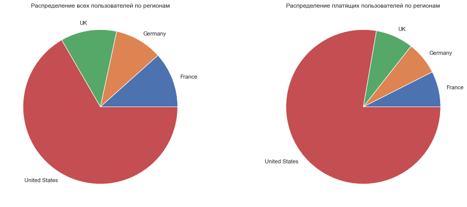

```python
#визуализируем результат
fig, ax = plt.subplots(1, 2, figsize = (17, 7),  squeeze=False)
ax[0][1].pie(region_users.payers, labels=region_users.region)
ax[0][1].set(title='Распределение платящих пользователей по регионам')
ax[0][0].pie(region_users.total_users, labels=region_users.region)
ax[0][0].set(title='Распределение всех пользователей по регионам')
plt.show()
```

Подавляющее большинство пользователей из США, доля платящих пользователей в США самая высокая - порядка 7ми процентов, в странах Европы - порядка 4х процентов.

переход к оглавлению

### Распределение пользователей по устройствам

```python
#устройства пользователей
profiles.device.unique()
```

```
array(['Mac', 'iPhone', 'PC', 'Android'], dtype=object)
```

```python
#построение таблицы с количество пользователей и долю платящих для каждого устройства.
device_users = (
    profiles.groupby('device')['user_id'].nunique().reset_index()
    .merge(profiles[profiles['payer']==True].groupby('device')['user_id'].nunique().reset_index(), on = 'device', how = 'left')
)
device_users.set_axis(['device', 'total_users', 'payers'], axis='columns', inplace=True)
device_users['payer_rate'] = device_users.payers / device_users.total_users
device_users.sort_values(by='payer_rate', ascending=False)
```

|  | device | total_users | payers | payer_rate |
| --- | --- | --- | --- | --- |
| 1 | Mac | 30042 | 1912 | 0.063644 |
| 3 | iPhone | 54479 | 3382 | 0.062079 |
| 0 | Android | 35032 | 2050 | 0.058518 |
| 2 | PC | 30455 | 1537 | 0.050468 |

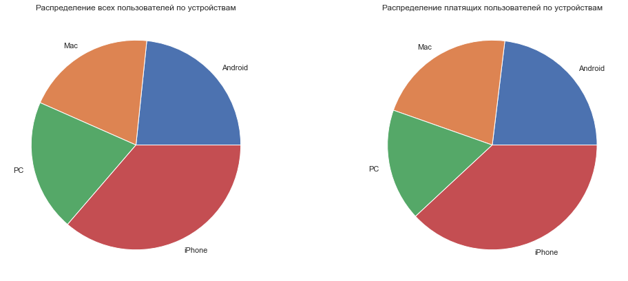

```python
# визуализируем результат
fig, ax = plt.subplots(1, 2, figsize = (17, 7),  squeeze=False)
ax[0][0].pie(device_users.total_users, labels=device_users.device)
ax[0][0].set(title='Распределение всех пользователей по устройствам')
ax[0][1].pie(device_users.payers, labels=device_users.device)
ax[0][1].set(title='Распределение платящих пользователей по устройствам')
plt.show()
```

Среди пользователей в качестве устройств - доминируют iPhone. Доля платящих пользователей выше всего у влдельцев Mac.

переход к оглавлению

### Распределение пользователей по рекламным каналам

```python
#каналы привлечения пользователей
profiles.channel.unique()
```

```
array(['FaceBoom', 'organic', 'AdNonSense', 'YRabbit', 'MediaTornado',
       'RocketSuperAds', 'LeapBob', 'TipTop', 'WahooNetBanner',
       'OppleCreativeMedia', 'lambdaMediaAds'], dtype=object)
```

```python
#построение таблицы с количеством пользователей и долю платящих для каждого канала привлечения
ch_users = (
    profiles.groupby('channel')['user_id'].nunique().reset_index()
    .merge(profiles[profiles['payer']==True].groupby('channel')['user_id'].nunique().reset_index(), on = 'channel', how = 'left')
)
ch_users.set_axis(['channel', 'total_users', 'payers'], axis='columns', inplace=True)
ch_users['payer_rate'] = ch_users.payers / ch_users.total_users
ch_users.sort_values(by='payer_rate', ascending=False)
```

|  | channel | total_users | payers | payer_rate |
| --- | --- | --- | --- | --- |
| 1 | FaceBoom | 29144 | 3557 | 0.122049 |
| 0 | AdNonSense | 3880 | 440 | 0.113402 |
| 9 | lambdaMediaAds | 2149 | 225 | 0.104700 |
| 6 | TipTop | 19561 | 1878 | 0.096007 |
| 5 | RocketSuperAds | 4448 | 352 | 0.079137 |
| 7 | WahooNetBanner | 8553 | 453 | 0.052964 |
| 8 | YRabbit | 4312 | 165 | 0.038265 |
| 3 | MediaTornado | 4364 | 156 | 0.035747 |
| 2 | LeapBob | 8553 | 262 | 0.030633 |
| 4 | OppleCreativeMedia | 8605 | 233 | 0.027077 |
| 10 | organic | 56439 | 1160 | 0.020553 |

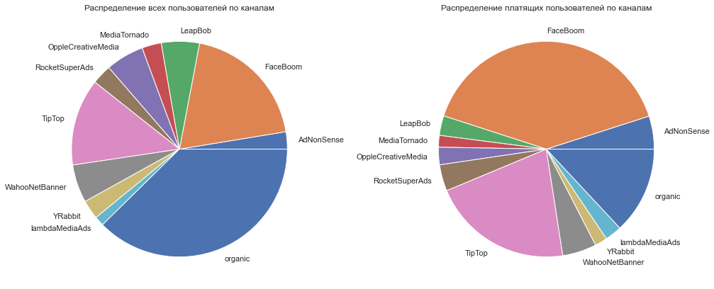

```python
# визуализируем результат
fig, ax = plt.subplots(1, 2, figsize = (17, 7),  squeeze=False)
ax[0][0].pie(ch_users.total_users, labels=ch_users.channel)
ax[0][0].set(title='Распределение всех пользователей по каналам')
ax[0][1].pie(ch_users.payers, labels=ch_users.channel)
ax[0][1].set(title='Распределение платящих пользователей по каналам')
plt.show()
```

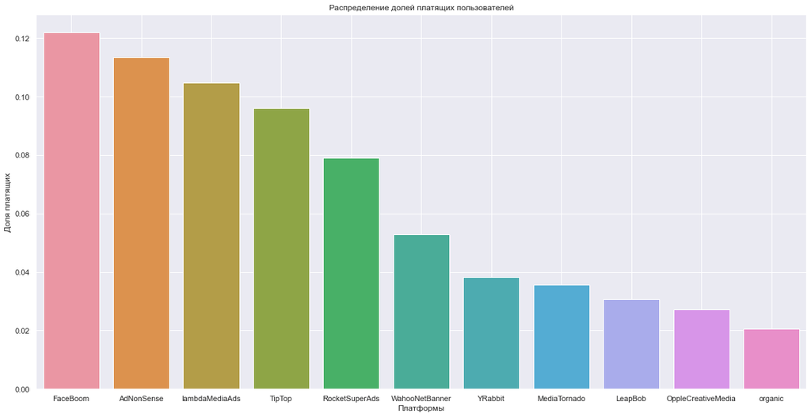

```python
#визуализация распределения долей платящих пользователей по каналам привлечения
ch_users_2 = ch_users.sort_values(by='payer_rate', ascending=False)
plt.figure(figsize=(20,10))
sns.barplot(data=ch_users_2, x="channel", y="payer_rate")
plt.title('Распределение долей платящих пользователей')
plt.xlabel('Платформы',fontsize=12)
plt.ylabel('Доля платящих',fontsize=12)
plt.grid(True)
plt.show()
```

Топ 5 платформ с наибольшей долей платящих пользователей:

- FaceBoom
- AdNonSense
- lambdaMediaAds
- TipTop
- RocketSuperAds

переход к оглавлению

### Вывод по исследовательскому анализу данных

- В исследуемых данных присутствуют данные о 4х странах: США, Франция, Германия и Британия.
- Подавляющее количество пользователей - в США, равно как и доля платящих пользователей - 7% против 4% в Европе.
- Приложением пользуются на 4х платформах: Mac, PC, iPhone и Android, где подавляющее большинство - пользователи iPhone, однако доля платящих пользователей немного выше у пользователей Mac.
- Рекламных каналов - 11, среди которых максимальная доля платящих пользователей у платформы FaceBoom и минимальная у канала Organic.

переход к оглавлению

## Маркетинг

TO DO:

- Посчитать общую сумму расходов на маркетинг;
- Выяснить, как траты распределены по рекламным источникам, то есть сколько денег потратили на каждый источник;
- Построить визуализацию динамики изменения расходов во времени (по неделям и месяцам) по каждому источнику.
- Узнать, сколько в среднем стоило привлечение одного пользователя (CAC) из каждого источника.

### Подсчёт общей суммы расходов на маркетинг

```python
#общая сумма расходов
costs.costs.sum()
```

```
105497.30000000002
```

переход к оглавлению

### Распределение трат по рекламным источникам

```python
#затраты на маркетинг по источникам
costs.groupby('channel')['costs'].sum().sort_values(ascending=False).reset_index()
```

|  | channel | costs |
| --- | --- | --- |
| 0 | TipTop | 54751.30 |
| 1 | FaceBoom | 32445.60 |
| 2 | WahooNetBanner | 5151.00 |
| 3 | AdNonSense | 3911.25 |
| 4 | OppleCreativeMedia | 2151.25 |
| 5 | RocketSuperAds | 1833.00 |
| 6 | LeapBob | 1797.60 |
| 7 | lambdaMediaAds | 1557.60 |
| 8 | MediaTornado | 954.48 |
| 9 | YRabbit | 944.22 |

Общая сумма затрат на маркетинг - 105497.3. Больше всего было потрачено на маркетинг в источниках: TipTop и FaceBoom. На них приходится более 80% от всех затрат.

переход к оглавлению

### Построение визуализации динамики изменения расходов по неделям и месяцам

```python
#добавим столбцы "месяц" и "неделя" в датафрейм costs
costs['dt'] = pd.to_datetime(costs['dt'])
costs['month'] = costs['dt'].dt.month
costs['week'] = costs['dt'].dt.isocalendar().week
```

```python
#check
costs.head()
```

|  | dt | channel | costs | month | week |
| --- | --- | --- | --- | --- | --- |
| 0 | 2019-05-01 | FaceBoom | 113.3 | 5 | 18 |
| 1 | 2019-05-02 | FaceBoom | 78.1 | 5 | 18 |
| 2 | 2019-05-03 | FaceBoom | 85.8 | 5 | 18 |
| 3 | 2019-05-04 | FaceBoom | 136.4 | 5 | 18 |
| 4 | 2019-05-05 | FaceBoom | 122.1 | 5 | 18 |

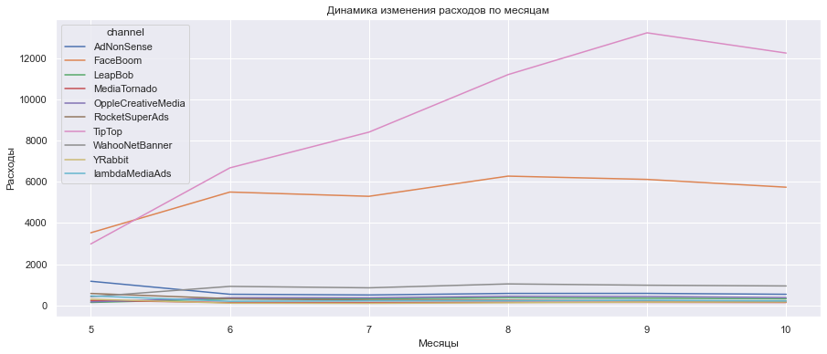

```python
#соберем сводную таблицу и по ней построим график динамики по месяцам
ax = costs.pivot_table(index='month', columns='channel', values='costs', aggfunc='sum').plot(grid=True, figsize=(15,6))
ax.set_title('Динамика изменения расходов по месяцам')
plt.xlabel('Месяцы')
plt.ylabel('Расходы')
plt.grid(True)
plt.show()
```

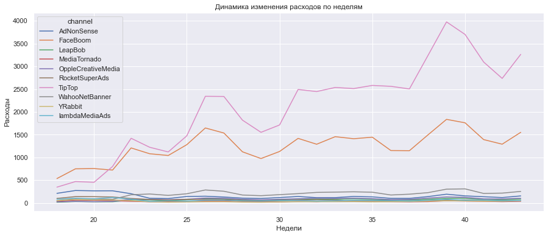

```python
#соберем сводную таблицу и по ней построим график динамики по неделям
ax = costs.pivot_table(index='week', columns='channel', values='costs', aggfunc='sum').plot(grid=True, figsize=(15,6))
ax.set_title('Динамика изменения расходов по неделям')
plt.xlabel('Недели')
plt.ylabel('Расходы')
plt.grid(True)
plt.show()
```

Наибольшую динамику показывают 2 платформы:

- FaceBoom;
- TipTop

переход к оглавлению

### Стоимость привлечения пользователей

```python
#собираем таблицу
ad_costs = ch_users.merge(costs.groupby('channel')['costs'].sum().reset_index(), on = 'channel', how = 'left')
```

```python
#исключаем органику
ad_costs = ad_costs.query('channel != "organic"')
```

```python
#check
ad_costs.sort_values(by='costs', ascending=False)
```

|  | channel | total_users | payers | payer_rate | costs |
| --- | --- | --- | --- | --- | --- |
| 6 | TipTop | 19561 | 1878 | 0.096007 | 54751.30 |
| 1 | FaceBoom | 29144 | 3557 | 0.122049 | 32445.60 |
| 7 | WahooNetBanner | 8553 | 453 | 0.052964 | 5151.00 |
| 0 | AdNonSense | 3880 | 440 | 0.113402 | 3911.25 |
| 4 | OppleCreativeMedia | 8605 | 233 | 0.027077 | 2151.25 |
| 5 | RocketSuperAds | 4448 | 352 | 0.079137 | 1833.00 |
| 2 | LeapBob | 8553 | 262 | 0.030633 | 1797.60 |
| 9 | lambdaMediaAds | 2149 | 225 | 0.104700 | 1557.60 |
| 3 | MediaTornado | 4364 | 156 | 0.035747 | 954.48 |
| 8 | YRabbit | 4312 | 165 | 0.038265 | 944.22 |

```python
#считаем стоимость привлечения одного пользователя, для чего разделим рекламные затраты на кол-во пользователей
ad_costs['cac'] = ad_costs.costs / ad_costs.total_users
```

```python
#check
ad_costs[['channel', 'cac']].sort_values(by='cac', ascending=False)
```

|  | channel | cac |
| --- | --- | --- |
| 6 | TipTop | 2.799003 |
| 1 | FaceBoom | 1.113286 |
| 0 | AdNonSense | 1.008054 |
| 9 | lambdaMediaAds | 0.724802 |
| 7 | WahooNetBanner | 0.602245 |
| 5 | RocketSuperAds | 0.412095 |
| 4 | OppleCreativeMedia | 0.250000 |
| 8 | YRabbit | 0.218975 |
| 3 | MediaTornado | 0.218717 |
| 2 | LeapBob | 0.210172 |

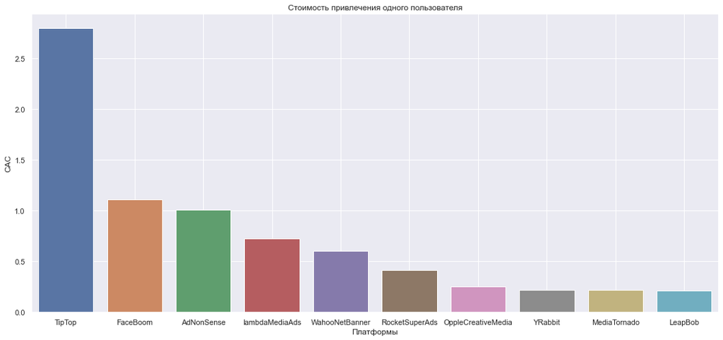

```python
#визуализация стоимости привлечения одного пользователя
ad_costs_visual = ad_costs.sort_values(by='cac', ascending=False)
plt.figure(figsize=(18,8))
sns.barplot(data=ad_costs_visual, x="channel", y="cac")
plt.title('Стоимость привлечения одного пользователя')
plt.xlabel('Платформы')
plt.ylabel('CAC')
plt.grid(True)
plt.show()
```

Наиболее высокая стоимость привлечения одного пользователя - TipTop, минимальная стоимость - LeapBob

переход к оглавлению

переход к оглавлению

## Оценка окупаемости рекламы

TO DO:

- Проанализировать окупаемость рекламы c помощью графиков LTV и ROI, а также графики динамики LTV, CAC и ROI.
- Проверить конверсию пользователей и динамику её изменения. То же самое сделать с удержанием пользователей. Построить и изучите графики конверсии и удержания.
- Проанализировать окупаемость рекламы с разбивкой по устройствам. Построить графики LTV и ROI, а также графики динамики LTV, CAC и ROI.
- Проанализировать окупаемость рекламы с разбивкой по странам. Построить графики LTV и ROI, а также графики динамики LTV, CAC и ROI.
- Проанализировать окупаемость рекламы с разбивкой по рекламным каналам. Построить графики LTV и ROI, а также графики динамики LTV, CAC и ROI.

Исключаем канал "organic", потому как пользователи оттуда достаются условно бесплатно.

### Анализ окупаемости c помощью графиков LTV и ROI

```python
profiles_no = profiles.query('channel != "organic"')
```

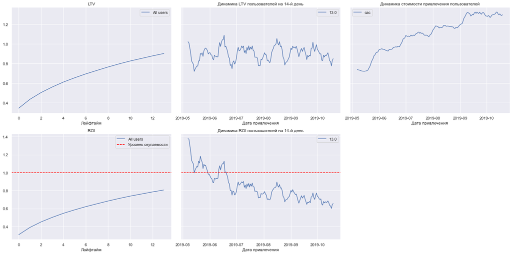

```python
# считаем LTV и ROI
ltv_raw, ltv_grouped, ltv_history, roi_grouped, roi_history = get_ltv(profiles_no, orders, observation_date, horizon_days)
# строим графики
plot_ltv_roi(ltv_grouped, ltv_history, roi_grouped, roi_history, horizon_days)
```

- Реклама не окупается. К концу двух недель ROI немного выше 80%;
- CAC показывает стабильный рост;
- LTV стабилен, качество пользователей не ухудшается.

переход к оглавлению

### Окупаемость рекламы с разбивкой по устройствам

Передадим параметру dimensions столбец device

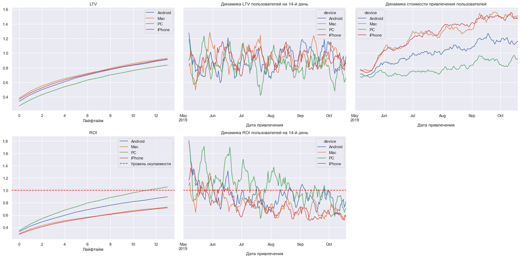

```python
#окупаемость с разбивкой по устройствам
dimensions = ['device']

ltv_raw, ltv_grouped, ltv_history, roi_grouped, roi_history = get_ltv(
    profiles_no, orders, observation_date, horizon_days, dimensions=dimensions
)

plot_ltv_roi(
    ltv_grouped, ltv_history, roi_grouped, roi_history, horizon_days, window=7
)
```

- Реклама не окупается везде, кроме PC;
- CAC растет на всех платформах;
- LTV стабилен везде;
- динамика стоимости привлечения пользователей значительно выше на устройствах Apple, после идут устройства Android

переход к оглавлению

### Окупаемость рекламы с разбивкой по странам

Передадим параметру dimensions столбец region

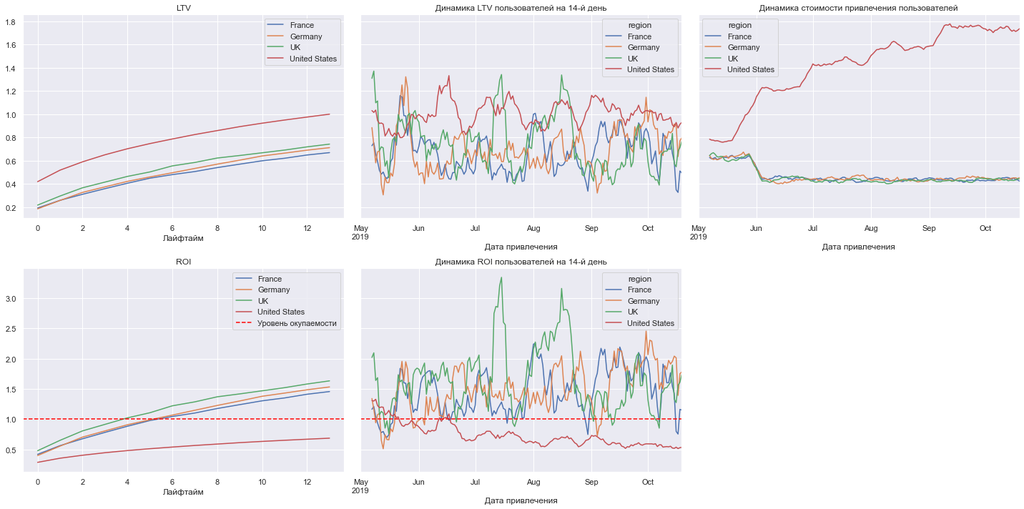

```python
#окупаемость с разбивкой по странам
dimensions = ['region']

ltv_raw, ltv_grouped, ltv_history, roi_grouped, roi_history = get_ltv(
    profiles_no, orders, observation_date, horizon_days, dimensions=dimensions
)

plot_ltv_roi(
    ltv_grouped, ltv_history, roi_grouped, roi_history, horizon_days, window=7
)
```

- В Европе реклама окупается уже к 6 дню, в а в США не окупается совсем;
- CAC растет в США, а в Европе резко снижается в июне и дальше держится стабильно низко;
- LTV пользователей из США самый высокий, но затраты на рекламу не окупаются

переход к оглавлению

### Окупаемость рекламы с разбивкой по рекламным каналам

Передадим параметру dimensions столбец channel

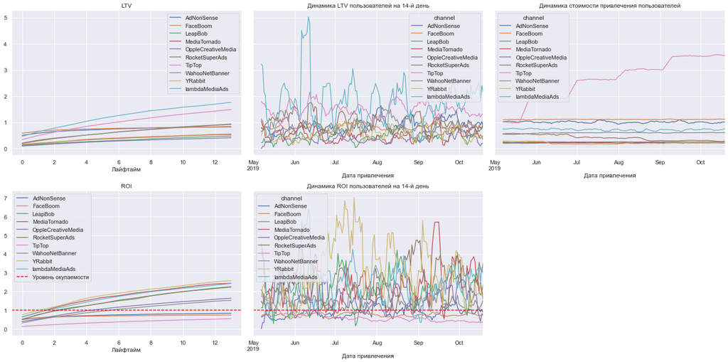

```python
#окупаемость с разбивкой по странам
dimensions = ['channel']

ltv_raw, ltv_grouped, ltv_history, roi_grouped, roi_history = get_ltv(
    profiles_no, orders, observation_date, horizon_days, dimensions=dimensions
)

plot_ltv_roi(
    ltv_grouped, ltv_history, roi_grouped, roi_history, horizon_days, window=7
)
```

- Во всех каналах, кроме TipTop, FaceBoom и AdNonSense реклама окупается;
- CAC растет в TipTop, а в остальных держится стабильно низко;
- Лидерами по окупаемости являются: YRabbit, MediaTornado, lambdaMediaAds т.е. источники с наименьшими маркетинговыми затратами.
- самый высокий LTV показывают платформы: lambdaMediaAds, TipTop

переход к оглавлению

### Конверсия пользователей

Посчитаем и визуализируем конверсию с помощью функций get_conversion() и plot_conversion()

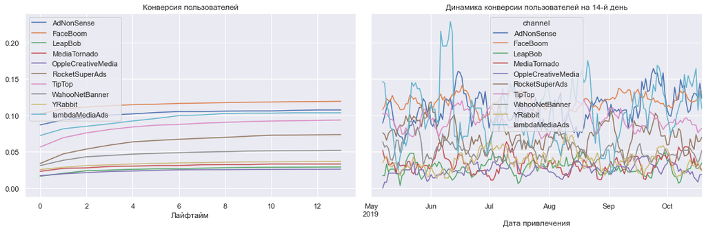

```python
#конверсия пользователей по источникам привлечения
dimensions = ['channel']

conversion_raw, conversion_grouped, conversion_history = get_conversion(
    profiles_no, orders, observation_date, horizon_days, dimensions=dimensions
)

plot_conversion(conversion_grouped, conversion_history, horizon_days)
```

С конверсией всё в порядке, рассмотрим удержание

Вызовем функции get_retention() и plot_retention(), чтобы рассчитать и отразить на графиках удержание.

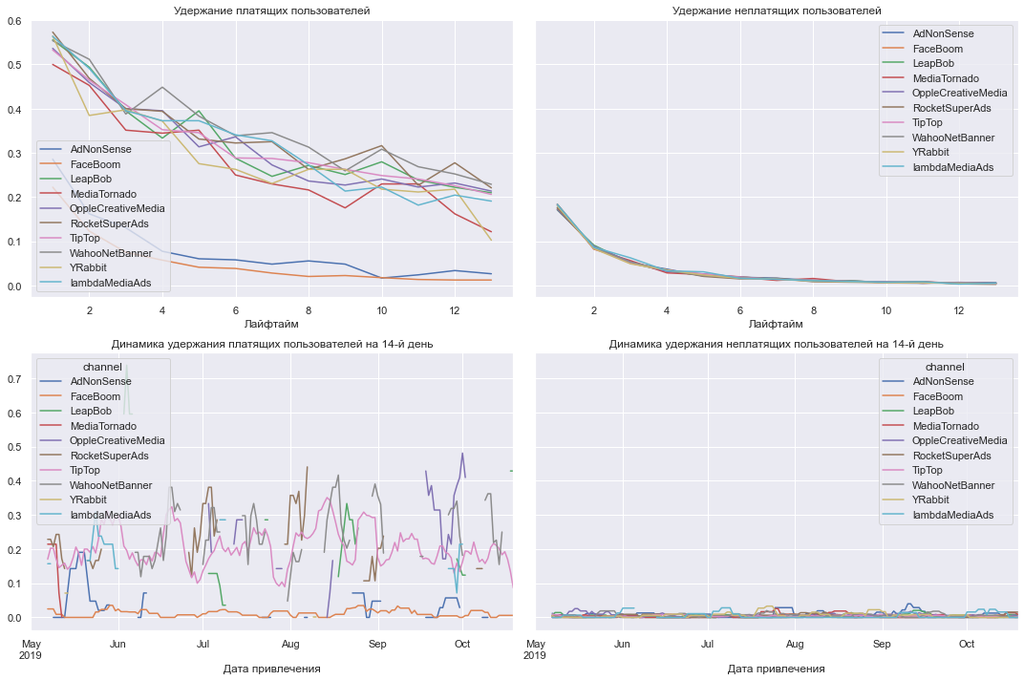

```python
#удержание пользователей по источникам привлечения
dimensions = ['channel']
retention_raw, retention_grouped, retention_history = get_retention(
    profiles_no, visits, observation_date, horizon_days, dimensions=dimensions
)

plot_retention(retention_grouped, retention_history, horizon_days)
```

Удержание пользователей из FaceBoom и AdNonSense гораздо ниже, чем пользователей из других источников. Удержание пользователей ТipTop довольно высокое, при конверсии выше среднего. Вероятная причина не окупаемости данного канала - слишком высокие расценки на рекламу.

переход к оглавлению

### Конверсия пользователей по регионам

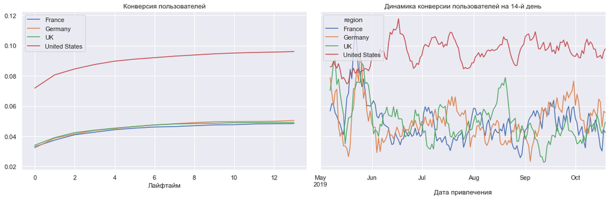

```python
 #конверсия с разбивкой по всем странам
dimensions = ['region']

conversion_raw, conversion_grouped, conversion_history = get_conversion(
    profiles_no, orders, observation_date, horizon_days, dimensions=dimensions
)

plot_conversion(conversion_grouped, conversion_history, horizon_days)
```

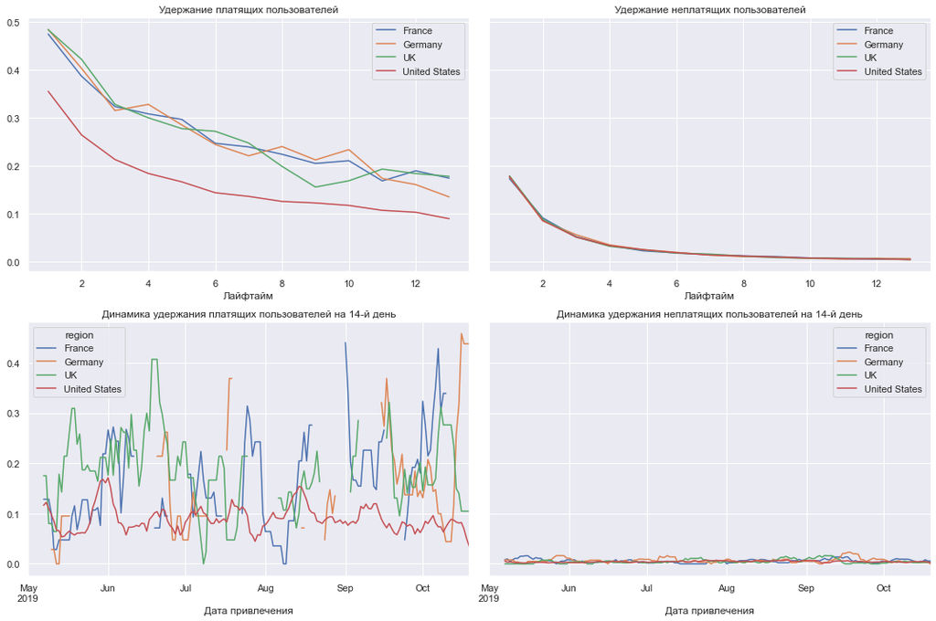

```python
#удержание с разбивкой по всем странам
dimensions = ['region']

retention_raw, retention_grouped, retention_history = get_retention(
    profiles_no, visits, observation_date, horizon_days, dimensions=dimensions
)

plot_retention(retention_grouped, retention_history, horizon_days)
```

Несмотря на огромные рекламные бюджеты и высокую конвверсию в США, удержание платящих пользователей заметно ниже, чем в Европе.

переход к оглавлению

### Выводы по окупаемости

- Реклама не окупается в каналах TipTop, FaceBoom и AdNonSense, в остальнах - окупается.
- По устройствам: окупается только на PC.
- В Европейских странах реклама окупается к 6му дню, в США - не окупается совсем.
- Проблемы окупаемости могут быть связаны со слишким высокими ценами на рекламу в канале TipTop.
- канал TipTop показывает наименьшую окупаемость инвестиций при наибольшей динамике стоимости привлечения клиентов. Вероятно, рекламная компания была направлена на не целевую аудиторию.

переход к оглавлению

## Каналы, устройства, платформы

```python
profiles.head()
```

|  | user_id | first_ts | channel | device | region | dt | month | payer | acquisition_cost |
| --- | --- | --- | --- | --- | --- | --- | --- | --- | --- |
| 0 | 599326 | 2019-05-07 20:58:57 | FaceBoom | Mac | United States | 2019-05-07 | 2019-05-01 | True | 1.088172 |
| 1 | 4919697 | 2019-07-09 12:46:07 | FaceBoom | iPhone | United States | 2019-07-09 | 2019-07-01 | False | 1.107237 |
| 2 | 6085896 | 2019-10-01 09:58:33 | organic | iPhone | France | 2019-10-01 | 2019-10-01 | False | 0.000000 |
| 3 | 22593348 | 2019-08-22 21:35:48 | AdNonSense | PC | Germany | 2019-08-22 | 2019-08-01 | False | 0.988235 |
| 4 | 31989216 | 2019-10-02 00:07:44 | YRabbit | iPhone | United States | 2019-10-02 | 2019-10-01 | False | 0.230769 |

### Распределение каналов по странам

```python
#каналы по странам
test_1 = (
    profiles[profiles.payer == True].pivot_table(index='channel',
                                                 columns = 'region',
                                                 values = 'user_id',
                                                 aggfunc='count')
    .reset_index()
    .sort_values('United States',ascending=False)
    .query('channel != "organic"')
)
test_1
```

| region | channel | France | Germany | UK | United States |
| --- | --- | --- | --- | --- | --- |
| 1 | FaceBoom | NaN | NaN | NaN | 3557.0 |
| 6 | TipTop | NaN | NaN | NaN | 1878.0 |
| 5 | RocketSuperAds | NaN | NaN | NaN | 352.0 |
| 8 | YRabbit | NaN | NaN | NaN | 165.0 |
| 3 | MediaTornado | NaN | NaN | NaN | 156.0 |
| 0 | AdNonSense | 150.0 | 142.0 | 148.0 | NaN |
| 2 | LeapBob | 90.0 | 69.0 | 103.0 | NaN |
| 4 | OppleCreativeMedia | 80.0 | 64.0 | 89.0 | NaN |
| 7 | WahooNetBanner | 152.0 | 148.0 | 153.0 | NaN |
| 9 | lambdaMediaAds | 82.0 | 67.0 | 76.0 | NaN |

Рекламные каналы в США и Европе не пересекаются.

Штаты:

- FaceBoom
- TipTop
- RocketSuperAds
- YRabbit
- MediaTornado

Европа:

- AdNonSense
- LeapBob
- OppleCreativeMedia
- WahooNetBanner
- lambdaMediaAds

переход к оглавлению

### Распределение устройств по каналам

```python
#устройства по каналам
test_2 = (
     profiles[profiles.payer == True].pivot_table(index='channel',
                                                  columns='region',
                                                  values='device',
                                                  aggfunc='nunique')
        .reset_index()
        .sort_values('United States')
        .query('channel != "organic"')
)
test_2
```

| region | channel | France | Germany | UK | United States |
| --- | --- | --- | --- | --- | --- |
| 1 | FaceBoom | NaN | NaN | NaN | 4.0 |
| 3 | MediaTornado | NaN | NaN | NaN | 4.0 |
| 5 | RocketSuperAds | NaN | NaN | NaN | 4.0 |
| 6 | TipTop | NaN | NaN | NaN | 4.0 |
| 8 | YRabbit | NaN | NaN | NaN | 4.0 |
| 0 | AdNonSense | 4.0 | 4.0 | 4.0 | NaN |
| 2 | LeapBob | 4.0 | 4.0 | 4.0 | NaN |
| 4 | OppleCreativeMedia | 4.0 | 4.0 | 4.0 | NaN |
| 7 | WahooNetBanner | 4.0 | 4.0 | 4.0 | NaN |
| 9 | lambdaMediaAds | 4.0 | 4.0 | 4.0 | NaN |

Каждый канал распространяется на все 4 устройства: Mac, iPhone, PC, Android.

переход к оглавлению

### Популярность девайсов

```python
#популярность девайсов
pop_dev = profiles.pivot_table(index='device', columns='region', values='user_id', aggfunc='nunique').reset_index()
pop_dev
```

| region | device | France | Germany | UK | United States |
| --- | --- | --- | --- | --- | --- |
| 0 | Android | 5252 | 4440 | 5141 | 20199 |
| 1 | Mac | 1838 | 1584 | 1778 | 24842 |
| 2 | PC | 6940 | 5945 | 7138 | 10432 |
| 3 | iPhone | 3420 | 3012 | 3518 | 44529 |

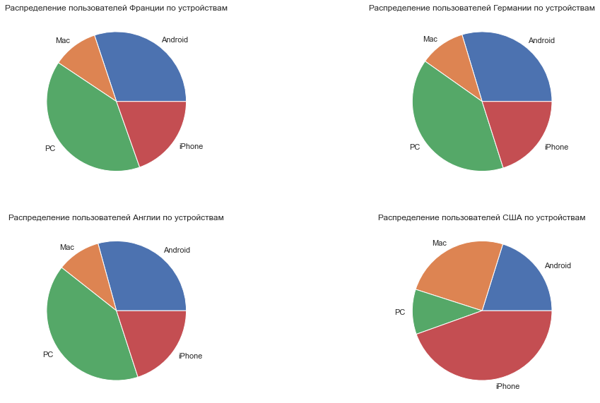

```python
#визуализация
fig, ax = plt.subplots(2, 2, figsize = (17, 10),  squeeze=False)
ax[0][0].pie(pop_dev['France'], labels=pop_dev.device)
ax[0][0].set(title='Распределение пользователей Франции по устройствам')
ax[0][1].pie(pop_dev['Germany'], labels=pop_dev.device)
ax[0][1].set(title='Распределение пользователей Германии по устройствам')
ax[1][0].pie(pop_dev['UK'], labels=pop_dev.device)
ax[1][0].set(title='Распределение пользователей Англии по устройствам')
ax[1][1].pie(pop_dev['United States'], labels=pop_dev.device)
ax[1][1].set(title='Распределение пользователей США по устройствам')
plt.show()
```

В странах Европы наибольшей популярностью обладают PC и Android. В США - iPhone и Mac

переход к оглавлению

### Привлеченные пользователи по каналам и устройствам

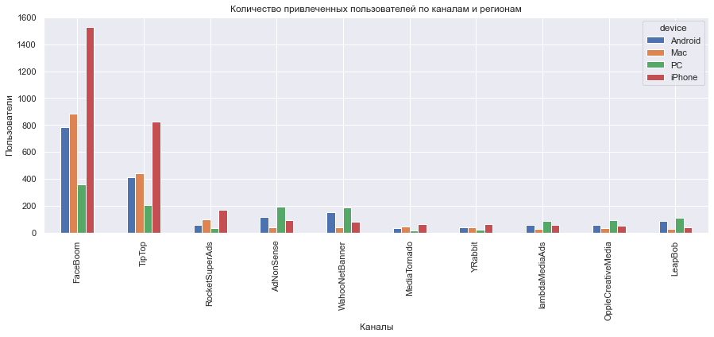

```python
#количество привлеченных пользователей по каналам и устройствам
test_3 = (
    profiles[profiles.payer == True].pivot_table(index='channel',
                                                 columns = 'device',
                                                 values = 'user_id',
                                                 aggfunc='count')
    .reset_index()
    .sort_values('iPhone', ascending=False)
    .query('channel != "organic"')
)
test_3.plot(x='channel', y=['Android', 'Mac', 'PC', 'iPhone'], kind='bar', grid=True, figsize=(15,5))
plt.title('Количество привлеченных пользователей по каналам и регионам')
plt.xlabel('Каналы')
plt.ylabel('Пользователи')
plt.show()
```

Среди 2х каналов с наибольшим количеством платящих пользователей(FaceBoom и TipTop), наиболшей популярностью полулярностью пользуется iPhone.

Одинаковые ли результаты показыкают пользователи FaceBoom в зависимости от платформы?

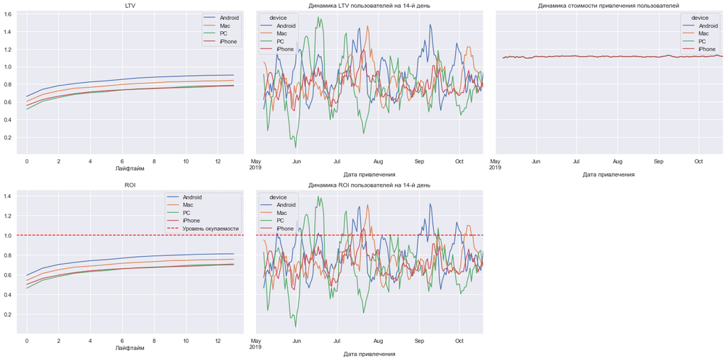

```python
test_cha = 'FaceBoom'
dimensions = ['device']

ltv_raw, ltv_grouped, ltv_history, roi_grouped, roi_history = get_ltv(
    profiles_no.query('channel in @test_cha'), orders, observation_date, horizon_days, dimensions=dimensions
)

plot_ltv_roi(
    ltv_grouped, ltv_history, roi_grouped, roi_history, horizon_days, window=7
)
```

С разной степенью, но одинаково не окупаются

переход к оглавлению

### Выводы по разделу

- Рекламные каналы в США и Европе не пересекаются
- В каждом рекламном канале представлены все 4 платформы;
- В странах Европы наибольшей популярностью обладают PC и Android. В США - iPhone и Mac
- Среди FaceBoom и TipTop наиболее популярен iPhone

переход к оглавлению

## Проседающие каналы

Рассмотрим отдельно 3 неокупающихся канала: TipTop, FaceBoom и AdNonSense. Рассмотрим показатели конверсии в этих каналах.

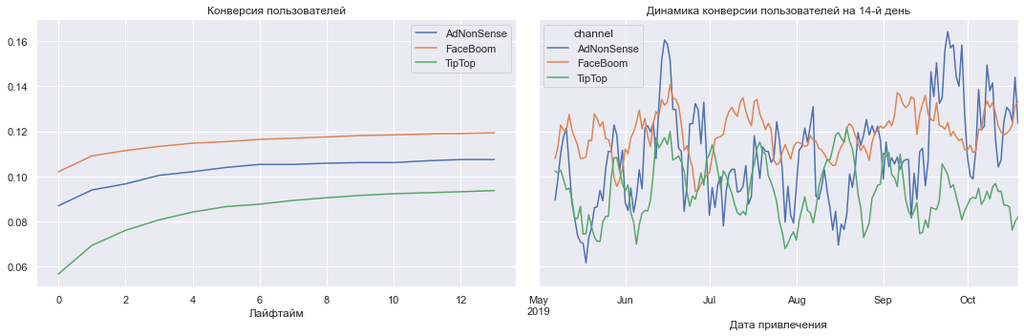

```python
low_ch = ['TipTop', 'FaceBoom', 'AdNonSense']
dimensions = ['channel']

conversion_raw, conversion_grouped, conversion_history = get_conversion(
    profiles_no.query('channel in @low_ch'), orders, observation_date, horizon_days, dimensions=dimensions
)

plot_conversion(conversion_grouped, conversion_history, horizon_days)
```

Пользователи конвертируются стабильно хорошо

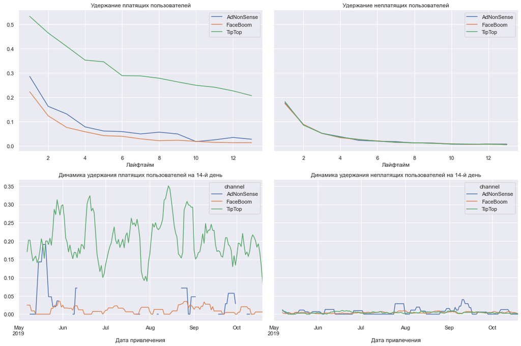

```python
#удержание
dimensions = ['channel']
retention_raw, retention_grouped, retention_history = get_retention(
    profiles_no.query('channel in @low_ch'), visits, observation_date, horizon_days, dimensions=dimensions
)

plot_retention(retention_grouped, retention_history, horizon_days)
```

Удержание пользователей из FaceBoom и AdNonSense гораздо ниже, чем у пользователей из TipTop. Вероятно, аудитория FaceBoom и AdNonSense не является целевой для продукта, либо есть техническая проблема в каналах.

переход к оглавлению

## Общий вывод

Задачей данного исследования являлось определение причин убытков компании. В ходе исследования была проанализирована активность пользователей и эффективность маркетинговых затрат.

Подавляющее большинство пользователей приложения - из США, доля платящих пользователей в США самая высокая - порядка 7ми процентов, в странах Европы - порядка 4х процентов.

Устройства с которых изпользуется приложение - имеет второстепенное значение. В странах Европы наибольшей популярностью обладают PC и Android. В США - iPhone и Mac.

В США не окупаются 2 канала из 5: TipTop и FaceBoom, в Европе 1 из 5 - AdNonSense.

Удержание пользователей ТipTop довольно высокое, при конверсии выше среднего. Вероятная причина не окупаемости данного канала - слишком высокие расценки на рекламу.

Примечание для маркетингового отдела: TipTop - канал с хорошим удержанием, стоит попробовать добиться лучших условий размещения рекламы. Объемы средств, выделяемых на этот рекламный канал - может стать хорошим аргументом в переговорах.

FaceBoom и AdNonSense - каналы с очень низким удержанием пользвателей. Реклама в них убыточка. Однако не следует сбрасывать со счетов хорошую конверсию пользователей. Бесспорно, рекламный бюджет стоит урезать.

Примечание для маркетингового отдела: следует проверить настройку рекламных показов, вероятно может быть ошибка в целевой аудитории. Также не исключается вероятность технической проблемы. Следует провести тесты пользовательского взаимодействия с приложением на этих рекламных платформах.

переход к оглавлению